# Differential Analysis of 5xFAD mouse models

2024-11-04

**Author:** Laura Heath, Sage Bionetworks.

*Adapted from code written by Ravi Pandey, Jackson Laboratories.*

*Edited by Jaclyn Beck, Sage Bionetworks.*

# Setup

The following data is obtained from The Jax.IU.Pitt_5XFAD Study (Jax.IU.Pitt_5XFAD), found here: syn21983020 and here: https://adknowledgeportal.synapse.org/Explore/Studies/DetailsPage/StudyData?Study=syn21983020

The following code will take the raw counts matrix and metadata files we downloaded in the first part of the workshop (`5XFAD_data_R_tutorial.qmd`) to run a basic differential expression analysis on a single time point (12 months) in male mice. You can amend the code to compare wild type and 5XFAD mice from either sex, at any time point.

We will need several new packages from Bioconductor to run this analysis:

```r
if (!requireNamespace("BiocManager", quietly = TRUE))
    install.packages("BiocManager")

BiocManager::install(c("DESeq2", "org.Mm.eg.db","GO.db", "EnhancedVolcano", "AnnotationDbi"))

# If necessary, install these packages as well
#install.packages(c("tidyverse", "ggplot2", "dplyr"))
```

Load necessary libraries.

```r
library(DESeq2)
library(ggplot2)
library(AnnotationDbi)
library(org.Mm.eg.db)
library(GO.db)
library(EnhancedVolcano)
library(tidyverse)
library(dplyr)
library(synapser)
```

# Download counts and metadata from Synapse

You can use the original counts matrix we downloaded in `5XFAD_data_r_tutorial.qmd`, along with the subsetted metadata with covariates of interest. The code below is a repeat of the code that fetches those files.

```r
synLogin()
```

```r
counts_id <- "syn22108847"
counts_file <- synGet(counts_id, downloadLocation = "files/")
counts <- read.delim(counts_file$path, check.names = FALSE)
head(counts)
```

```
##              gene_id 32043rh 32044rh 32046rh 32047rh 32048rh 32049rh 32050rh
## 1    ENSG00000080815   22554       0       0       0   16700       0       0
## 2    ENSG00000142192  344489       4       0       1  260935       6       8
## 3 ENSMUSG00000000001    5061    3483    3941    3088    2756    3067    2711
## 4 ENSMUSG00000000003       0       0       0       0       0       0       0
## 5 ENSMUSG00000000028     208     162     138     127      95     154     165
## 6 ENSMUSG00000000031      44      17      14      28      23      24      14
##   32052rh 32053rh 32057rh 32059rh 32061rh 32062rh 32065rh 32067rh 32068rh
## 1   19748   14023       0   17062       0   15986      10       0   18584
## 2  337456  206851       1  264748       0  252248     172       4  300398
## 3    3334    3841    4068    3306    4076    3732    3940    4238    3257
## 4       0       0       0       0       0       0       0       0       0
## 5     124     103     164     116     108     134     204     239     148
## 6      30      24      35      41      40      32      34      47      22
##   32070rh 32073rh 32074rh 32075rh 32078rh 32081rh 32088rh 32640rh 46105rh
```

[output cut: 48 more lines]

Download the three metadata files we need, in order to join specimen IDs from the counts matrix to individual IDs in the clinical metadata.

```r
# RNA assay metadata
rna_metaID <- "syn22110328"
synGet(rna_metaID, downloadLocation = "files/")
rna_meta <- read_csv("files/Jax.IU.Pitt_5XFAD_assay_RNAseq_metadata.csv", show_col_types = FALSE)

# biospecimen metadata
bio_metaID <- "syn22103213"
synGet(bio_metaID, downloadLocation = "files/")
bio_meta <- read_csv("files/Jax.IU.Pitt_5XFAD_biospecimen_metadata.csv", show_col_types = FALSE)

# individual metadata
ind_metaID <- "syn22103212"
synGet(ind_metaID, downloadLocation = "files/")
ind_meta <- read_csv("files/Jax.IU.Pitt_5XFAD_individual_metadata.csv", show_col_types = FALSE)
```

Join the three metadata files by IDs in common.

```r
joined_meta <- rna_meta %>% #start with the rnaseq assay metadata
  left_join(bio_meta, by = "specimenID") %>%  #join rows from biospecimen that match specimenID
  left_join(ind_meta, by = "individualID") # join rows from individual that match individualID

joined_meta
```

```
## # A tibble: 72 × 53
##    specimenID platform   RIN   rnaBatch libraryBatch sequencingBatch libraryPrep
##    <chr>      <chr>      <lgl>    <dbl>        <dbl>           <dbl> <chr>
##  1 32043rh    IlluminaN… NA           1            1               1 polyAselec…
##  2 32044rh    IlluminaN… NA           1            1               1 polyAselec…
##  3 32046rh    IlluminaN… NA           1            1               1 polyAselec…
##  4 32047rh    IlluminaN… NA           1            1               1 polyAselec…
##  5 32049rh    IlluminaN… NA           1            1               1 polyAselec…
##  6 32057rh    IlluminaN… NA           1            1               1 polyAselec…
##  7 32061rh    IlluminaN… NA           1            1               1 polyAselec…
##  8 32065rh    IlluminaN… NA           1            1               1 polyAselec…
##  9 32067rh    IlluminaN… NA           1            1               1 polyAselec…
## 10 32070rh    IlluminaN… NA           1            1               1 polyAselec…
## # ℹ 62 more rows
## # ℹ 46 more variables: libraryPreparationMethod <lgl>, isStranded <lgl>,
## #   readStrandOrigin <lgl>, runType <chr>, readLength <dbl>,
## #   individualID <dbl>, specimenIdSource <chr>, organ <chr>, tissue <chr>,
## #   BrodmannArea <lgl>, sampleStatus <chr>, tissueWeight <lgl>,
## #   tissueVolume <lgl>, nucleicAcidSource <lgl>, cellType <lgl>,
## #   fastingState <lgl>, isPostMortem <lgl>, samplingAge <lgl>, …
```

Create a timepoint variable (Months since birth) from the `dateBirth` and `dateDeath` fields in the metadata.

```r
library(lubridate)

# convert columns of strings to month-date-year format
joined_meta_time <- joined_meta %>%
  mutate(dateBirth = mdy(dateBirth), dateDeath = mdy(dateDeath)) %>%
  # create a new column that subtracts dateBirth from dateDeath in days, then divide by 30 to get months
  mutate(timepoint = as.numeric(difftime(dateDeath, dateBirth, units ="days"))/30) %>%
  # convert numeric ages to timepoint categories
  mutate(timepoint = case_when(timepoint > 10 ~ "12 mo",
                               timepoint < 10 & timepoint > 5 ~ "6 mo",
                               timepoint < 5 ~ "4 mo"))

# check that the timepoint column looks ok (should be 6 mice in each group)
joined_meta_time %>%
  dplyr::group_by(sex, genotype, timepoint) %>%
  dplyr::count()
```

```
## # A tibble: 12 × 4
## # Groups:   sex, genotype, timepoint [12]
##    sex    genotype         timepoint     n
##    <chr>  <chr>            <chr>     <int>
##  1 female 5XFAD_carrier    12 mo         6
##  2 female 5XFAD_carrier    4 mo          6
##  3 female 5XFAD_carrier    6 mo          6
##  4 female 5XFAD_noncarrier 12 mo         6
##  5 female 5XFAD_noncarrier 4 mo          6
##  6 female 5XFAD_noncarrier 6 mo          6
##  7 male   5XFAD_carrier    12 mo         6
##  8 male   5XFAD_carrier    4 mo          6
##  9 male   5XFAD_carrier    6 mo          6
## 10 male   5XFAD_noncarrier 12 mo         6
## 11 male   5XFAD_noncarrier 4 mo          6
## 12 male   5XFAD_noncarrier 6 mo          6
```

Select the covariates needed for the analysis

```r
covars <- joined_meta_time %>%
  dplyr::select(individualID, specimenID, sex, genotype, timepoint)
```

Clean up the `covars` data

```r
# coerce covars into a dataframe, label the rows by specimenID, and check the result
covars <- as.data.frame(covars)
rownames(covars) <- covars$specimenID
covars
```

```
##         individualID specimenID    sex         genotype timepoint
## 32043rh        32043    32043rh female    5XFAD_carrier     12 mo
## 32044rh        32044    32044rh   male 5XFAD_noncarrier     12 mo
## 32046rh        32046    32046rh   male 5XFAD_noncarrier     12 mo
## 32047rh        32047    32047rh   male 5XFAD_noncarrier     12 mo
## 32049rh        32049    32049rh female 5XFAD_noncarrier     12 mo
## 32057rh        32057    32057rh female 5XFAD_noncarrier     12 mo
## 32061rh        32061    32061rh   male 5XFAD_noncarrier     12 mo
## 32065rh        32065    32065rh female 5XFAD_noncarrier     12 mo
## 32067rh        32067    32067rh female 5XFAD_noncarrier     12 mo
## 32070rh        32070    32070rh female 5XFAD_noncarrier     12 mo
## 32073rh        32073    32073rh   male 5XFAD_noncarrier     12 mo
## 32074rh        32074    32074rh   male 5XFAD_noncarrier     12 mo
## 46105rh        46105    46105rh female 5XFAD_noncarrier      6 mo
## 46106rh        46106    46106rh female 5XFAD_noncarrier      6 mo
## 46107rh        46107    46107rh female 5XFAD_noncarrier      6 mo
## 46108rh        46108    46108rh   male 5XFAD_noncarrier      6 mo
## 46109rh        46109    46109rh   male 5XFAD_noncarrier      6 mo
## 46110rh        46110    46110rh   male 5XFAD_noncarrier      6 mo
## 46112rh        46112    46112rh female 5XFAD_noncarrier      6 mo
## 46115rh        46115    46115rh female 5XFAD_noncarrier      6 mo
## 46121rh        46121    46121rh female 5XFAD_noncarrier      6 mo
## 46131rh        46131    46131rh female 5XFAD_noncarrier      4 mo
## 46138rh        46138    46138rh female 5XFAD_noncarrier      4 mo
## 46862rh        46862    46862rh female 5XFAD_noncarrier      4 mo
## 46872rh        46872    46872rh   male 5XFAD_noncarrier      6 mo
## 46873rh        46873    46873rh   male 5XFAD_noncarrier      6 mo
## 46876rh        46876    46876rh   male 5XFAD_noncarrier      6 mo
## 46877rh        46877    46877rh   male 5XFAD_noncarrier      4 mo
## 46881rh        46881    46881rh female 5XFAD_noncarrier      4 mo
## 46884rh        46884    46884rh   male 5XFAD_noncarrier      4 mo
## 46887rh        46887    46887rh female    5XFAD_carrier      4 mo
## 46888rh        46888    46888rh   male 5XFAD_noncarrier      4 mo
## 46891rh        46891    46891rh   male 5XFAD_noncarrier      4 mo
## 46893rh        46893    46893rh female 5XFAD_noncarrier      4 mo
## 46895rh        46895    46895rh   male 5XFAD_noncarrier      4 mo
## 46897rh        46897    46897rh   male 5XFAD_noncarrier      4 mo
## 32048rh        32048    32048rh female    5XFAD_carrier     12 mo
## 32050rh        32050    32050rh female 5XFAD_noncarrier     12 mo
## 32052rh        32052    32052rh female    5XFAD_carrier     12 mo
```

[output cut: 18 more lines]

```
## 46867rh        46867    46867rh   male    5XFAD_carrier      4 mo
## 46868rh        46868    46868rh   male    5XFAD_carrier      4 mo
## 46871rh        46871    46871rh female    5XFAD_carrier      6 mo
## 46874rh        46874    46874rh   male    5XFAD_carrier      6 mo
## 46875rh        46875    46875rh   male    5XFAD_carrier      6 mo
## 46878rh        46878    46878rh   male    5XFAD_carrier      4 mo
## 46879rh        46879    46879rh   male    5XFAD_carrier      4 mo
## 46882rh        46882    46882rh female    5XFAD_carrier      4 mo
## 46883rh        46883    46883rh female    5XFAD_carrier      4 mo
## 46885rh        46885    46885rh female 5XFAD_noncarrier      4 mo
## 46886rh        46886    46886rh female    5XFAD_carrier      6 mo
## 46889rh        46889    46889rh   male    5XFAD_carrier      6 mo
## 46890rh        46890    46890rh   male    5XFAD_carrier      6 mo
## 46892rh        46892    46892rh   male    5XFAD_carrier      6 mo
## 46896rh        46896    46896rh   male    5XFAD_carrier      4 mo
```

Order the data (counts columns and metadata rows MUST be in the same order), and subset the counts matrix and metadata to include only 12 month old male mice

```r
rawdata <- counts %>% column_to_rownames("gene_id")
rawdata <- rawdata[, rownames(covars)]

meta.12M.Male <- covars %>%
  subset(sex == "male" & timepoint == "12 mo")

dat <- as.matrix(rawdata[, colnames(rawdata) %in% rownames(meta.12M.Male)])
```

This leaves us with 12 samples, 6 per genotype:

```r
meta.12M.Male %>%
  group_by(sex, genotype, timepoint) %>%
  count()
```

```
## # A tibble: 2 × 4
## # Groups:   sex, genotype, timepoint [2]
##   sex   genotype         timepoint     n
##   <chr> <chr>            <chr>     <int>
## 1 male  5XFAD_carrier    12 mo         6
## 2 male  5XFAD_noncarrier 12 mo         6
```

Verify that the columns in `dat` are in the same order as the specimenIDs in `meta.12M.Male`:

```r
all(colnames(dat) == meta.12M.Male$specimenID)
```

```
## [1] TRUE
```

We should now have:

1. A data.frame of metadata for 12-month-old male mice
2. A matrix of counts where each row is a gene and each column is a single specimen

We can now analyze this data with DESeq2.

# Differential Expression Analysis using DESeq2

Set up data for analysis. All samples are male, 12 month old mice, so we are only interested in looking at the effect of genotype on the data. We specify this for DESeq2 by setting the `design` argument to `~ genotype`. We want to make sure `genotype` is a factor before using it with DESeq2.

```r
meta.12M.Male$genotype <- factor(meta.12M.Male$genotype)

ddsHTSeq <- DESeqDataSetFromMatrix(countData = dat,
                                   colData = meta.12M.Male,
                                   design = ~ genotype)
```

Filter out genes that have all zero counts across all samples. You can also use more stringent criteria like only keeping genes that have at least *X* counts in at least *Y* samples, but for this workshop we will just remove zero-genes.

```r
paste("Total genes before filtering:", nrow(ddsHTSeq))
```

```
## [1] "Total genes before filtering: 55489"
```

```r
ddsHTSeq <- ddsHTSeq[rowSums(counts(ddsHTSeq)) >= 1,]

paste("Total genes after filtering:", nrow(ddsHTSeq))
```

```
## [1] "Total genes after filtering: 40784"
```

Set wild-type mice (5XFAD_noncarrier) as the reference genotype, so the comparison is 5XFAD_carrier - 5XFAD_noncarrier.

```r
ddsHTSeq$genotype <- relevel(ddsHTSeq$genotype, ref = "5XFAD_noncarrier")
```

## Run DESeq

This function normalizes the read counts, estimates dispersions, and fits the linear model using the formula we specified in `design` above (`~ genotype`)

```r
dds <- DESeq(ddsHTSeq, parallel = TRUE)
```

## Extract a table of results

The significance threshold can be set using the `alpha` argument of the `results` function. Here we use 0.05.

```r
res <- results(dds, alpha = 0.05)
summary(res)
```

```
##
## out of 40784 with nonzero total read count
## adjusted p-value < 0.05
## LFC > 0 (up)       : 1091, 2.7%
## LFC < 0 (down)     : 492, 1.2%
## outliers [1]       : 33, 0.081%
## low counts [2]     : 15803, 39%
## (mean count < 6)
## [1] see 'cooksCutoff' argument of ?results
## [2] see 'independentFiltering' argument of ?results
```

```r
head(as.data.frame(res))
```

```
##                        baseMean log2FoldChange      lfcSE       stat
## ENSG00000080815      8063.75087    16.43362659 0.83494694 19.6822407
## ENSG00000142192    123183.70706    16.53067797 0.37385139 44.2172436
## ENSMUSG00000000001   3737.92736     0.01485591 0.04670563  0.3180754
## ENSMUSG00000000028    138.56440    -0.07125899 0.15554445 -0.4581262
## ENSMUSG00000000031     29.29858     0.67055831 0.35732817  1.8765896
## ENSMUSG00000000037    123.64893    -0.21840176 0.15610915 -1.3990324
##                          pvalue         padj
## ENSG00000080815    3.061625e-86 2.121706e-83
## ENSG00000142192    0.000000e+00 0.000000e+00
## ENSMUSG00000000001 7.504278e-01 9.471513e-01
## ENSMUSG00000000028 6.468618e-01 9.196556e-01
## ENSMUSG00000000031 6.057437e-02 3.637962e-01
## ENSMUSG00000000037 1.618033e-01 5.809593e-01
```

Map Ensembl IDs to gene symbol names and Entrez IDs. This time, we’ll use a different package to translate mouse Ensembl IDs to gene names. Run these two functions and they will be called up when assembling results from the differential expression analysis.

```r
# functions to extract entrezid and symbols from ENSEMBL IDs
map_symbol.rname <- function(x) {
  mapIds(org.Mm.eg.db, keys = row.names(x), column = "SYMBOL",
         keytype = "ENSEMBL", multiVals = "first")
}

map_eid.rname <- function(x) {
  mapIds(org.Mm.eg.db, keys = row.names(x), column = "ENTREZID",
         keytype = "ENSEMBL", multiVals = "first")
}
```

```r
All_res <- as.data.frame(res) %>%
  mutate(symbol = map_symbol.rname(.), .before = baseMean) %>%
  mutate(EntrezGene = map_eid.rname(.), .after = symbol)

#label human gene names
All_res["ENSG00000080815", "symbol"] <- "PSEN1"
All_res["ENSG00000142192", "symbol"] <- "APP"

head(All_res)
```

```
##                    symbol EntrezGene     baseMean log2FoldChange      lfcSE
## ENSG00000080815     PSEN1       <NA>   8063.75087    16.43362659 0.83494694
## ENSG00000142192       APP       <NA> 123183.70706    16.53067797 0.37385139
## ENSMUSG00000000001  Gnai3      14679   3737.92736     0.01485591 0.04670563
## ENSMUSG00000000028  Cdc45      12544    138.56440    -0.07125899 0.15554445
## ENSMUSG00000000031    H19      14955     29.29858     0.67055831 0.35732817
## ENSMUSG00000000037  Scml2     107815    123.64893    -0.21840176 0.15610915
##                          stat       pvalue         padj
## ENSG00000080815    19.6822407 3.061625e-86 2.121706e-83
## ENSG00000142192    44.2172436 0.000000e+00 0.000000e+00
## ENSMUSG00000000001  0.3180754 7.504278e-01 9.471513e-01
## ENSMUSG00000000028 -0.4581262 6.468618e-01 9.196556e-01
## ENSMUSG00000000031  1.8765896 6.057437e-02 3.637962e-01
## ENSMUSG00000000037 -1.3990324 1.618033e-01 5.809593e-01
```

# Plot results

Volcano plot of differential expression results: all genes with p < 0.05 and log2FC > 0.1

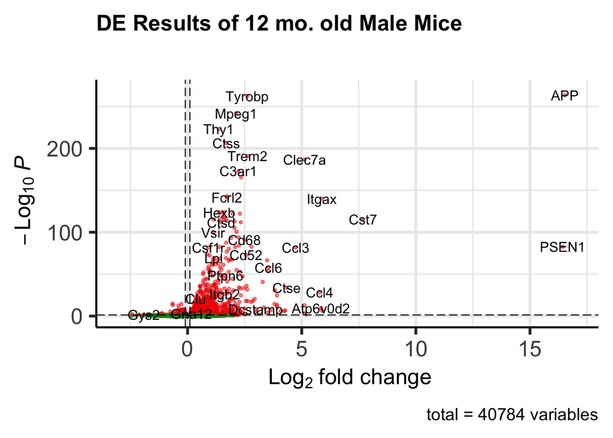

```r
  plot_DEGvolcano <- EnhancedVolcano(All_res,
                                     lab = (All_res$symbol),
                                     x = 'log2FoldChange',
                                     y = 'padj', legendPosition = 'none',
                                     title = 'DE Results of 12 mo. old Male Mice',
                                     subtitle = '',
                                     FCcutoff = 0.1,
                                     pCutoff = 0.05,
                                     xlim = c(-3, 17),
                                     pointSize = 1,
                                     labSize = 4
                                     )
  plot_DEGvolcano
```

Save results table and plot:

```r
All_res$ensembl <- row.names(All_res)
write.csv(All_res, file="5XFAD_DEresults_12mo_males.csv", row.names=FALSE)

ggsave("VolcanoPlot.png", width = 8, height = 6, units = "in")
```